# What technology is crazy about developers around the world?

```python
import lightgbm as lgb
import optuna
from optuna.logging import disable_default_handler
from optuna.integration.lightgbm  import LightGBMTuner,LightGBMTunerCV
import shap

from sklearn.model_selection import train_test_split
from sklearn.preprocessing import StandardScaler
from sklearn.model_selection import StratifiedKFold
from sklearn.metrics import mean_squared_error

import numpy as np
import pandas as pd
import matplotlib.pyplot as plt
import seaborn as sns
from pprint import pprint
```

```python
shap.__version__
```

```
'0.35.0'
```

# 2020 Developer Survey

Stack Overflow, which runs the developer community, announced the annual developer survey "2020 Developer Survey" on May 27th. Stack Overflow offers a community site for developers, with over 50 million unique visitors. The Developer Survey is the company's annual survey, and this is the 10th time this year. The survey was conducted in February 2020, with approximately 65,000 developers responding on a global basis.

```python
%matplotlib inline
df = pd.read_csv('./survey_results_public_2020.csv')
schema = pd.read_csv('./survey_results_schema_2020.csv')
df.head(3)
```

|  | Respondent | MainBranch | Hobbyist | Age | Age1stCode | CompFreq | CompTotal | ConvertedComp | Country | CurrencyDesc | ... | SurveyEase | SurveyLength | Trans | UndergradMajor | WebframeDesireNextYear | WebframeWorkedWith | WelcomeChange | WorkWeekHrs | YearsCode | YearsCodePro |
| --- | --- | --- | --- | --- | --- | --- | --- | --- | --- | --- | --- | --- | --- | --- | --- | --- | --- | --- | --- | --- | --- |
| 0 | 1 | I am a developer by profession | Yes | NaN | 13 | Monthly | NaN | NaN | Germany | European Euro | ... | Neither easy nor difficult | Appropriate in length | No | Computer science, computer engineering, or sof... | ASP.NET Core | ASP.NET;ASP.NET Core | Just as welcome now as I felt last year | 50.0 | 36 | 27 |
| 1 | 2 | I am a developer by profession | No | NaN | 19 | NaN | NaN | NaN | United Kingdom | Pound sterling | ... | NaN | NaN | NaN | Computer science, computer engineering, or sof... | NaN | NaN | Somewhat more welcome now than last year | NaN | 7 | 4 |
| 2 | 3 | I code primarily as a hobby | Yes | NaN | 15 | NaN | NaN | NaN | Russian Federation | NaN | ... | Neither easy nor difficult | Appropriate in length | NaN | NaN | NaN | NaN | Somewhat more welcome now than last year | NaN | 4 | NaN |

3 rows × 61 columns

# What technology is crazy about developers around the world? What do you expect next?

```python
def sum_tec(var_list):
    """
    input: list of valiable (***WorkedWith ,***DesireNextYear)
    output: dataframe

    The number of each target is counted and stored in the data frame.

    """
    df1=pd.DataFrame()
    for var in var_list:

        d=defaultdict(int)
        for index, row in pd.DataFrame(df[var].value_counts()).iterrows():
            #print (index, row[0])
            lang_list=index.split(";")
            for lang in lang_list:
                d[lang] += int(row[0])

        df1 = pd.concat([df1,pd.DataFrame.from_dict(d, orient='index',columns=[var])],axis=1)

    return(df1.sort_values(var_list[0]))

def gap_df(df):
    """
    input  :dataframe which columns  about ***WorkedWith ,***DesireNextYear.
    output :display dataframe whith bar

    """
    df['Be expected'] =  df[df.columns[1]] - df[df.columns[0]]
    display(df.sort_values('Be expected',ascending=False).style.bar(subset=['Be expected'], align='mid', color=['#d65f5f', '#5fba7d']))


def now_next(comp_list,title):
    """
    input:  list of valiable (***WorkedWith ,***DesireNextYear)
            text of plot title
    output: plot and dataframe with bar

    """
    df=sum_tec(comp_list)
    df.plot.barh(figsize=[10,5])
    plt.title(title)
    plt.show()
    gap_df(df)
```

## What is most popular Language ?

Python is still very popular. The library is abundant, fresh, and there is a lot of information, so I feel like I can do anything. However, it seems that Rust, which I often hear recently, is good. Let's try it next time. There are many languages I don't know. I haven't studied enough.

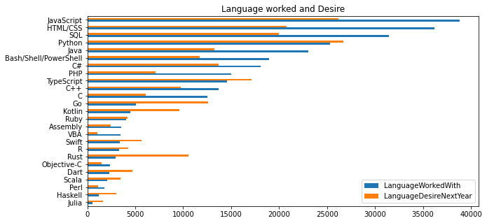

|  | LanguageWorkedWith | LanguageDesireNextYear | Be expected |
| --- | --- | --- | --- |
| Rust | 2929 | 10563 | 7634 |
| Go | 5038 | 12605 | 7567 |
| Kotlin | 4468 | 9575 | 5107 |
| TypeScript | 14578 | 17150 | 2572 |
| Dart | 2280 | 4742 | 2462 |
| Swift | 3397 | 5643 | 2246 |
| Haskell | 1222 | 2996 | 1774 |
| Scala | 2052 | 3465 | 1413 |
| Python | 25287 | 26682 | 1395 |
| Julia | 519 | 1661 | 1142 |
| R | 3288 | 4271 | 983 |
| Ruby | 4046 | 4184 | 138 |
| Perl | 1796 | 1150 | -646 |
| Objective-C | 2340 | 1525 | -815 |
| Assembly | 3553 | 2469 | -1084 |
| VBA | 3499 | 1055 | -2444 |
| C++ | 13707 | 9756 | -3951 |
| C# | 18041 | 13674 | -4367 |
| C | 12487 | 6091 | -6396 |
| Bash/Shell/PowerShell | 18980 | 11728 | -7252 |
| PHP | 15007 | 7106 | -7901 |
| Java | 23074 | 13264 | -9810 |
| SQL | 31413 | 19970 | -11443 |
| JavaScript | 38822 | 26188 | -12634 |
| HTML/CSS | 36181 | 20771 | -15410 |

```python
comp_list=["LanguageWorkedWith","LanguageDesireNextYear"]
title="Language worked and Desire"
now_next(comp_list,title)
```

## What is most popular platform ?

The cloud has become widespread and Linux has become the standard.Will Windows, which has been supporting our business for a long time, be chased? Starting with Docker, which grew up on Linux, expectations for Kubernetes are high. It's the tide of new technology.  
There are many AWS users, but there are high expectations for Google Cloud, which is strong in AI. (This Notebook is also working on Google Cloud)

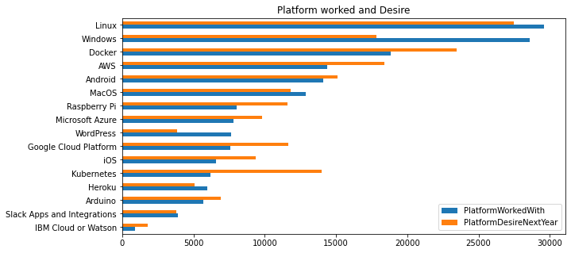

|  | PlatformWorkedWith | PlatformDesireNextYear | Be expected |
| --- | --- | --- | --- |
| Kubernetes | 6178 | 14009 | 7831 |
| Docker | 18851 | 23458 | 4607 |
| Google Cloud Platform | 7569 | 11648 | 4079 |
| AWS | 14389 | 18381 | 3992 |
| Raspberry Pi | 8010 | 11614 | 3604 |
| iOS | 6562 | 9357 | 2795 |
| Microsoft Azure | 7830 | 9816 | 1986 |
| Arduino | 5712 | 6895 | 1183 |
| Android | 14101 | 15085 | 984 |
| IBM Cloud or Watson | 876 | 1813 | 937 |
| Slack Apps and Integrations | 3922 | 3791 | -131 |
| Heroku | 5974 | 5071 | -903 |
| MacOS | 12898 | 11793 | -1105 |
| Linux | 29600 | 27475 | -2125 |
| WordPress | 7654 | 3847 | -3807 |
| Windows | 28595 | 17816 | -10779 |

```python
comp_list=["PlatformWorkedWith","PlatformDesireNextYear"]
title="Platform worked and Desire"
now_next(comp_list,title)
```

## What is most popular Database ?

I'm not familiar with Databese. I know that MySQL and PostgreSQL are major. I recently learned about the power of the Columner database. This is Yandex's ClickHouse (https://clickhouse.tech/). Very lightweight and fast. It is indispensable for handling big data. There are various databases, each of which has its advantages and disadvantages. It's difficult to decide which database to choose.The columnar database Cassandra is also fast, isn't it? there are many technologies that Database does not know. let's study...

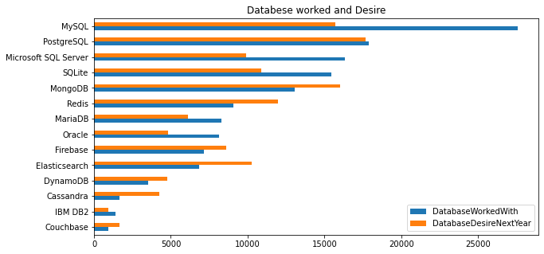

|  | DatabaseWorkedWith | DatabaseDesireNextYear | Be expected |
| --- | --- | --- | --- |
| Elasticsearch | 6817 | 10269 | 3452 |
| MongoDB | 13086 | 16024 | 2938 |
| Redis | 9056 | 11977 | 2921 |
| Cassandra | 1654 | 4227 | 2573 |
| Firebase | 7128 | 8600 | 1472 |
| DynamoDB | 3497 | 4773 | 1276 |
| Couchbase | 937 | 1678 | 741 |
| PostgreSQL | 17892 | 17681 | -211 |
| IBM DB2 | 1421 | 935 | -486 |
| MariaDB | 8312 | 6126 | -2186 |
| Oracle | 8155 | 4794 | -3361 |
| SQLite | 15434 | 10909 | -4525 |
| Microsoft SQL Server | 16336 | 9876 | -6460 |
| MySQL | 27559 | 15734 | -11825 |

```python
comp_list=["DatabaseWorkedWith","DatabaseDesireNextYear"]
title="Databese worked and Desire"
now_next(comp_list,title)
```

## What is most popular collaboration tool ?

Stack Overflow is growing fast. (Because it's a Stack Overflow survey) Github is no longer common sense.It may be the platform most frequently used by developers.

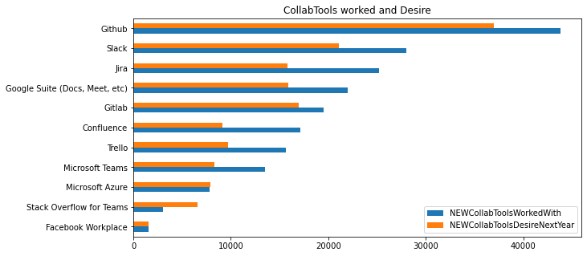

|  | NEWCollabToolsWorkedWith | NEWCollabToolsDesireNextYear | Be expected |
| --- | --- | --- | --- |
| Stack Overflow for Teams | 3057 | 6557 | 3500 |
| Microsoft Azure | 7849 | 7877 | 28 |
| Facebook Workplace | 1580 | 1570 | -10 |
| Gitlab | 19545 | 16974 | -2571 |
| Microsoft Teams | 13518 | 8356 | -5162 |
| Trello | 15655 | 9731 | -5924 |
| Google Suite (Docs, Meet, etc) | 21952 | 15909 | -6043 |
| Github | 43786 | 36996 | -6790 |
| Slack | 28018 | 21119 | -6899 |
| Confluence | 17122 | 9153 | -7969 |
| Jira | 25222 | 15796 | -9426 |

```python
comp_list=["NEWCollabToolsWorkedWith","NEWCollabToolsDesireNextYear"]
title="CollabTools worked and Desire"
now_next(comp_list,title)
```

## What is most popular web framework ?

I'm not a web developer, so I'm not sure. This course (Udacity) deals with Flask, but there seems to be a technology that is drawing more attention.

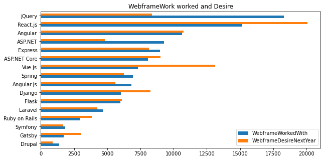

|  | WebframeWorkedWith | WebframeDesireNextYear | Be expected |
| --- | --- | --- | --- |
| Vue.js | 7322 | 13142 | 5820 |
| React.js | 15167 | 20071 | 4904 |
| Django | 6014 | 8237 | 2223 |
| Gatsby | 1703 | 2998 | 1295 |
| ASP.NET Core | 8082 | 9018 | 936 |
| Ruby on Rails | 2944 | 3849 | 905 |
| Angular | 10617 | 10762 | 145 |
| Flask | 6005 | 6097 | 92 |
| Symfony | 1851 | 1692 | -159 |
| Laravel | 4680 | 4260 | -420 |
| Drupal | 1369 | 889 | -480 |
| Spring | 6941 | 6241 | -700 |
| Express | 8961 | 8128 | -833 |
| Angular.js | 6826 | 5601 | -1225 |
| ASP.NET | 9258 | 4818 | -4440 |
| jQuery | 18316 | 8382 | -9934 |

```python
comp_list=["WebframeWorkedWith","WebframeDesireNextYear"]
title="WebframeWork worked and Desire"
now_next(comp_list,title)
```

## Other technologies

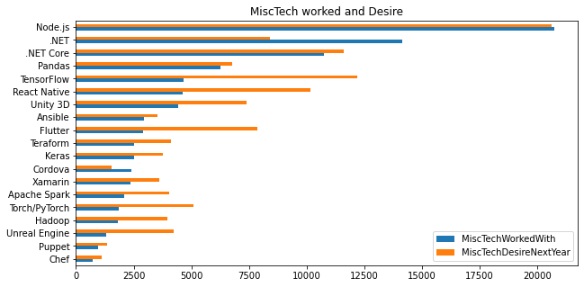

|  | MiscTechWorkedWith | MiscTechDesireNextYear | Be expected |
| --- | --- | --- | --- |
| TensorFlow | 4652 | 12211 | 7559 |
| React Native | 4626 | 10175 | 5549 |
| Flutter | 2897 | 7881 | 4984 |
| Torch/PyTorch | 1872 | 5101 | 3229 |
| Unity 3D | 4413 | 7404 | 2991 |
| Unreal Engine | 1316 | 4249 | 2933 |
| Hadoop | 1798 | 3973 | 2175 |
| Apache Spark | 2089 | 4025 | 1936 |
| Teraform | 2518 | 4104 | 1586 |
| Keras | 2504 | 3749 | 1245 |
| Xamarin | 2357 | 3593 | 1236 |
| .NET Core | 10755 | 11602 | 847 |
| Ansible | 2955 | 3528 | 573 |
| Pandas | 6253 | 6758 | 505 |
| Puppet | 945 | 1346 | 401 |
| Chef | 733 | 1119 | 386 |
| Node.js | 20741 | 20612 | -129 |
| Cordova | 2419 | 1534 | -885 |
| .NET | 14144 | 8399 | -5745 |

```python
comp_list=["MiscTechWorkedWith","MiscTechDesireNextYear"]
title="MiscTech worked and Desire"
now_next(comp_list,title)
```

# What are the factors related to salary?

What is the income of developers around the world? You can't be a developer just because you like technology. You also need money, right?

It's a bit old, but I'll use the information from the 2017 survey. Let's explore the factors related to the salary of developers around the world.

```python
#サラリーとの関係が深い

def clean_data(df,target,remove):
    '''
    INPUT
    df     -pandas dataframe
    target -Objective variable
    remove -remove variable

    OUTPUT
    X - A matrix holding all of the variables you want to consider when predicting the response
    y - the corresponding response vector

    This function cleans df using the following steps to produce X and y:
    1. Drop all the rows with no object variable
    2. Create X as all the columns that are not the object column
    3. Create y as the object column
    4. Drop the some columns related with object from X
    5. For each numeric variable in X, fill the column with the mean value of the column.
    6. Create dummy columns for all the categorical variables in X, drop the original columns
    '''
    # Drop rows with missing salary values

    print("Target:",target)

    df = df.dropna(subset=[target], axis=0)
    y = df[target]

    #Drop respondent and expected salary columns
    print("remove:",remove)
    df = df.drop(remove, axis=1)

    # Fill numeric columns with the mean
    num_vars = df.select_dtypes(include=['float', 'int']).columns
    for col in num_vars:
        df[col].fillna((df[col].mean()), inplace=True)

    # Dummy the categorical variables
    cat_vars = df.select_dtypes(include=['object']).copy().columns
    for var in  cat_vars:
        # for each cat add dummy var, drop original column
        #df = pd.concat([df.drop(var, axis=1), pd.get_dummies(df[var], prefix=var, prefix_sep='_', drop_first=True)], axis=1)
        df = pd.concat([df.drop(var, axis=1), df[var].str.get_dummies(sep='; ').add_prefix(var+'_')], axis=1)

    X = df
    return X, y
```

```python
df = pd.read_csv('./survey_results_public_2017.csv')
schema = pd.read_csv('./survey_results_schema_2017.csv')
```

```python
#Use the function to create X and y
target='Salary'
remove=['Respondent', 'ExpectedSalary', 'Salary']


#target="ConvertedComp"
#remove=["ConvertedComp","CompTotal","CurrencySymbol","CurrencyDesc"]
#remove=['Respondent', 'Salary']
#target='CareerSatisfaction'
#remove=['JobSatisfaction','CareerSatisfaction']

X, y = clean_data(df,target,remove)

import re
X=X.rename(columns=lambda x: re.sub(r"[^a-zA-Z0-9_]","",x))
```

```
Target: Salary
remove: ['Respondent', 'ExpectedSalary', 'Salary']
```

```python
pd.set_option('display.max_columns', 10000)
X
```

|  | CareerSatisfaction | JobSatisfaction | HoursPerWeek | StackOverflowSatisfaction | Professional_Professionaldeveloper | ProgramHobby_No | ProgramHobby_YesIcontributetoopensourceprojects | ProgramHobby_YesIprogramasahobby | ProgramHobby_Yesboth | Country_Afghanistan | Country_Albania | Country_Anguilla | Country_Argentina | Country_Armenia | Country_Australia | Country_Austria | Country_Azerbaidjan | Country_Bahrain | Country_Bangladesh | Country_Barbados | Country_Belarus | Country_Belgium | Country_Bermuda | Country_Bolivia | Country_BosniaHerzegovina | Country_Botswana | Country_Brazil | Country_Bulgaria | Country_Cambodia | … |
| --- | --- | --- | --- | --- | --- | --- | --- | --- | --- | --- | --- | --- | --- | --- | --- | --- | --- | --- | --- | --- | --- | --- | --- | --- | --- | --- | --- | --- | --- | --- |
| 2 | 8.0 | 9.0 | 2.64292 | 8.000000 | 1 | 0 | 0 | 0 | 1 | 0 | 0 | 0 | 0 | 0 | 0 | 0 | 0 | 0 | 0 | 0 | 0 | 0 | 0 | 0 | 0 | 0 | 0 | 0 | 0 | … |
| 14 | 8.0 | 8.0 | 2.64292 | 8.000000 | 1 | 0 | 0 | 1 | 0 | 0 | 0 | 0 | 0 | 0 | 0 | 0 | 0 | 0 | 0 | 0 | 0 | 0 | 0 | 0 | 0 | 0 | 0 | 0 | 0 | … |
| 17 | 9.0 | 8.0 | 2.64292 | 8.000000 | 1 | 0 | 0 | 0 | 1 | 0 | 0 | 0 | 0 | 0 | 0 | 0 | 0 | 0 | 0 | 0 | 0 | 0 | 0 | 0 | 0 | 0 | 0 | 0 | 0 | … |
| 18 | 5.0 | 3.0 | 2.64292 | 8.511858 | 1 | 0 | 0 | 1 | 0 | 0 | 0 | 0 | 0 | 0 | 0 | 0 | 0 | 0 | 0 | 0 | 0 | 0 | 0 | 0 | 0 | 0 | 0 | 0 | 0 | … |
| 22 | 8.0 | 9.0 | 2.64292 | 8.000000 | 1 | 1 | 0 | 0 | 0 | 0 | 0 | 0 | 0 | 0 | 0 | 0 | 0 | 0 | 0 | 0 | 0 | 0 | 0 | 0 | 0 | 0 | 0 | 0 | 0 | … |
| ... | ... | ... | ... | ... | ... | ... | ... | ... | ... | ... | ... | ... | ... | ... | ... | ... | ... | ... | ... | ... | ... | ... | ... | ... | ... | ... | ... | ... | ... | … |
| 51371 | 7.0 | 7.0 | 2.64292 | 8.000000 | 1 | 1 | 0 | 0 | 0 | 0 | 0 | 0 | 0 | 0 | 0 | 0 | 0 | 0 | 0 | 0 | 0 | 0 | 0 | 0 | 0 | 0 | 0 | 0 | 0 | … |
| 51378 | 10.0 | 10.0 | 2.64292 | 10.000000 | 1 | 0 | 1 | 0 | 0 | 0 | 0 | 0 | 0 | 0 | 0 | 0 | 0 | 0 | 0 | 0 | 0 | 0 | 0 | 0 | 0 | 0 | 0 | 0 | 0 | … |
| 51382 | 9.0 | 5.0 | 0.00000 | 7.000000 | 1 | 0 | 0 | 1 | 0 | 0 | 0 | 0 | 0 | 0 | 0 | 0 | 0 | 0 | 0 | 0 | 0 | 0 | 0 | 0 | 0 | 0 | 0 | 0 | 0 | … |
| 51387 | 7.0 | 3.0 | 5.00000 | 9.000000 | 1 | 0 | 0 | 1 | 0 | 0 | 0 | 0 | 0 | 0 | 0 | 0 | 0 | 0 | 0 | 0 | 0 | 0 | 0 | 0 | 0 | 0 | 0 | 0 | 0 | … |
| 51390 | 6.0 | 7.0 | 1.00000 | 9.000000 | 1 | 0 | 0 | 1 | 0 | 0 | 0 | 0 | 0 | 0 | 0 | 0 | 0 | 0 | 0 | 0 | 0 | 0 | 0 | 0 | 0 | 0 | 0 | 0 | 0 | … |

12891 rows × 1103 columns

```python
y
```

```
2        113750.000000
14       100000.000000
17       130000.000000
18        82500.000000
22       100764.000000
             ...
51371     74193.548387
51378    107526.881720
51382     32258.064516
51387     58000.000000
51390     40000.000000
Name: Salary, Length: 12891, dtype: float64
```

```python
X_train, X_test, y_train, y_test = train_test_split(X, y)
```

```python
dtrain = lgb.Dataset(X_train, label=y_train)
eval_data = lgb.Dataset(X_test, label=y_test)
```

```python
class TunerCVCheckpointCallback(object):

    def __init__(self):
        self.cv_boosters = {}

    @staticmethod
    def params_to_hash(params):
        params_hash = hash(frozenset(params.items()))
        return params_hash

    def get_trained_model(self, params):
        params_hash = self.params_to_hash(params)
        return self.cv_boosters[params_hash]

    def __call__(self, env):
        params_hash = self.params_to_hash(env.params)
        if params_hash not in self.cv_boosters:
            self.cv_boosters[params_hash] = env.model
```

```python
import optuna.integration.lightgbm as lgb
disable_default_handler()


folds = StratifiedKFold(n_splits=3, shuffle=True, random_state=42)

checkpoint_cb = TunerCVCheckpointCallback()
callbacks = [checkpoint_cb]


param = {
        'objective': 'regression',
        #'objective': 'multiclass',
        'metric': 'rmse',
        'verbosity': 0,
        'boosting_type': 'gbdt',
    }

best = lgb.LightGBMTuner(param,
                 dtrain,
                 valid_sets=eval_data,
                 early_stopping_rounds=100,
                 num_boost_round=1000,
                 #folds=folds,
                 #callbacks=callbacks,

                        )
best.run()
```

```python
model=best.get_best_booster()
#model= checkpoint_cb.get_trained_model(best.best_params)
```

```python
pprint(best.best_params)
```

```
{'bagging_fraction': 1.0,
 'bagging_freq': 0,
 'boosting_type': 'gbdt',
 'feature_fraction': 0.8999999999999999,
 'feature_pre_filter': False,
 'lambda_l1': 1.2827043541644444e-05,
 'lambda_l2': 2.830160665021305e-05,
 'metric': 'rmse',
 'min_child_samples': 20,
 'num_leaves': 31,
 'objective': 'regression',
 'verbosity': 0}
```

```python
y_pred_tuned =model.predict(X_test)
```

```python
y_pred_tuned[0]
```

```
14916.943545893613
```

```python
tuned_metric = mean_squared_error(y_test, y_pred_tuned)
print('tuned model metric: ', tuned_metric)
```

```
tuned model metric:  352670587.6661628
```

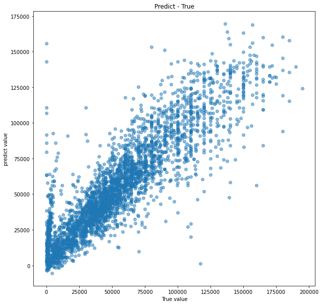

```python
import matplotlib.pyplot as plt
plt.figure(figsize=(10, 10))
plt.plot(y_test, y_pred_tuned,'o',alpha=0.5)
plt.title("Predict - True")
plt.ylabel("predict value")
plt.xlabel("True value")
plt.show()
```

```python
#shap_values = explainer.shap_values(X)
```

```python
shap.initjs()
explainer = shap.TreeExplainer(model)
shap_values = explainer.shap_values(X)
```

```
Setting feature_perturbation = "tree_path_dependent" because no background data was given.
```

```python
shap.force_plot(explainer.expected_value, shap_values[0,:], X.iloc[0,:])
```

[output not shown]

## find factors related to salary

Next, we will identify the factors that influence Shap, which is one of the explainable AIs using game theory. Red represents the impact on the prediction value when the variable is high (plus or minus is represented by the plot on the horizontal axis. Blue represents the impact on the prediction (plus or minus) when the variable is low.

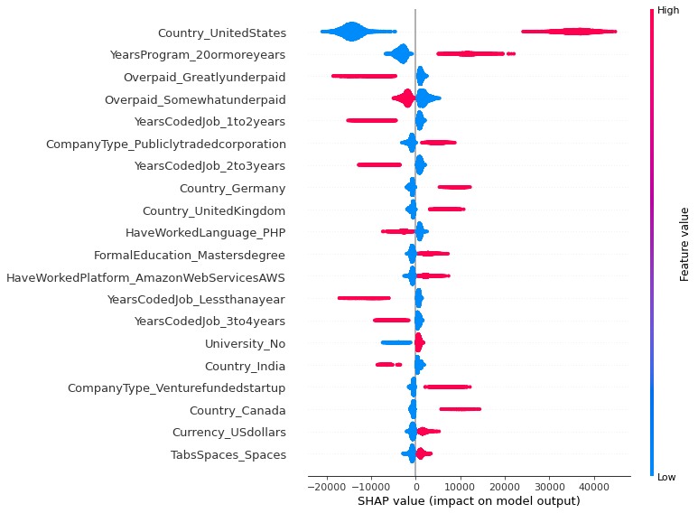

```python
shap.summary_plot(shap_values, X)
```

- In the United States, the forecast value is quite positive, and the range is wide (it shows that the range of salary is also large). This is influenced by the high-priced areas of Silicon Valley.
- In addition, a wealth of engineers over 20 years have contributed to the positive forecast. On the contrary, it can be seen that the predicted value is swinging negative for young engineers who have little experience for 1 to 3 years.
- In addition, European engineers and engineers with a master degree have a positive forecast.
- In addition, being a venture company is also a positive forecast value.

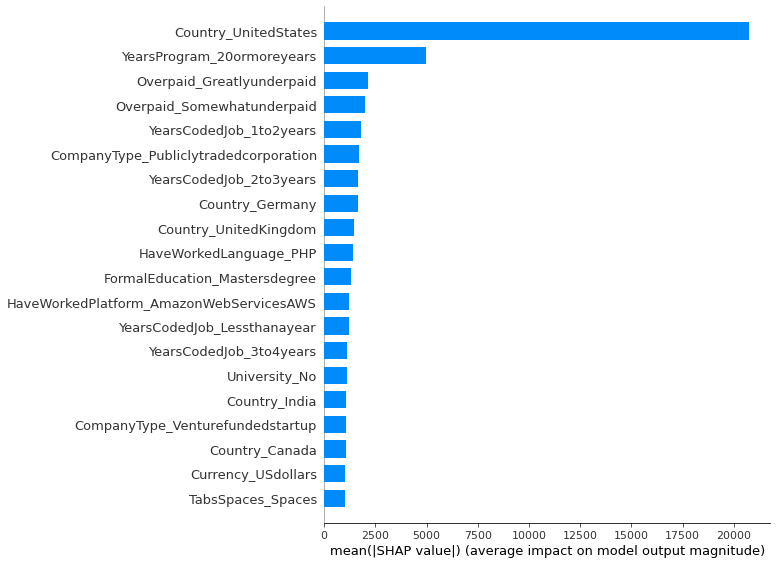

```python
shap.summary_plot(shap_values, X, plot_type="bar")
```

It is also possible to provide information similar to Tree-based Featue Impottance. With this information, you can see the degree of impact, but you can not confirm how much each variable will have a positive effect or a negative effect, which is the advantage of SHAP.